# analysisscript

Sophia Drewry

10/15/2021

This script loads the cleaned and processed data to perform some formal statistical fitting

```r
# load needed packages. make sure they are installed.
library(dplyr) #for data processing
library(here) #to set paths
library(tidymodels) #to fit models
```

```r
library(dotwhisker) #for box and ehiskers plots
library(ggplot2)
```

#Load data

```r
# note the use of the here() package and not absolute paths
dataSPOT <- here::here("data","processed_data","smalldta.rds")
dataSPOT2 <- here::here("data","processed_data","feverdta.rds")
# load data.
# note. processeddta is our main cleaned fata set. Fever data is just those who have fever,
processeddta <-readRDS(dataSPOT)
feverdta <-readRDS(dataSPOT2)
# take a look at the main data
dplyr::glimpse(processeddta)
```

```
## Rows: 730
## Columns: 10
## $ Fatigue           <fct> Yes, Yes, Yes, Yes, Yes, Yes, Yes, Yes, Yes, Yes, Ye…
## $ ChillsSweats      <fct> No, No, Yes, Yes, Yes, Yes, Yes, Yes, Yes, No, Yes, …
## $ SwollenLymphNodes <fct> Yes, Yes, Yes, Yes, Yes, No, No, No, Yes, No, Yes, Y…
## $ Pharyngitis       <fct> Yes, Yes, Yes, Yes, Yes, Yes, Yes, No, No, No, Yes, …
## $ Insomnia          <fct> No, No, Yes, Yes, Yes, No, No, Yes, Yes, Yes, Yes, Y…
## $ Headache          <fct> Yes, Yes, Yes, Yes, Yes, Yes, No, Yes, Yes, Yes, Yes…
## $ SubjectiveFever   <fct> Yes, Yes, Yes, Yes, Yes, Yes, Yes, Yes, Yes, No, Yes…
## $ CoughIntensity    <fct> Severe, Severe, Mild, Moderate, None, Moderate, Seve…
## $ BodyTemp          <dbl> 98.3, 100.4, 100.8, 98.8, 100.5, 98.4, 102.5, 98.4, …
## $ Nausea            <fct> No, No, Yes, Yes, Yes, Yes, No, No, Yes, Yes, Yes, Y…
```

### End goal:

- Main continuous outcome of interest = Body temperature
- Main categorical outcome = Nausea
- We want to see if the other symptoms are correlated with (predict) those outcomes we looked at in the EDA. The predictors of interest are as follows:
- Fatigue (y/n)
- CoughIntensity (none/mild/moderate/severe)
- ChillsSweats (y/n)
- SwollenLymphNodes (y/n)
- Pharyngitis (y/n)
- Insomnia (y/n)
- Headache (y/n)
- SubjectiveFever (y/n)

# Model 1. Fitting a linear model to BodyTemp using Chill Sweats the main predictor of interest

```r
# Using the tidymodels package, I am going to set up the linear model
# Set the engine
lm_mod <-  linear_reg() %>%
  set_engine("lm")
# Now I am fitting the model
lm_fit <-
  lm_mod %>%
  fit(BodyTemp ~ ChillsSweats, data = processeddta)
tidy(lm_fit)
```

```
## # A tibble: 2 × 5
##   term            estimate std.error statistic  p.value
##   <chr>              <dbl>     <dbl>     <dbl>    <dbl>
## 1 (Intercept)       98.6       0.104    947.   0
## 2 ChillsSweatsYes    0.410     0.115      3.58 0.000373
```

### Model as box and whiskers plot

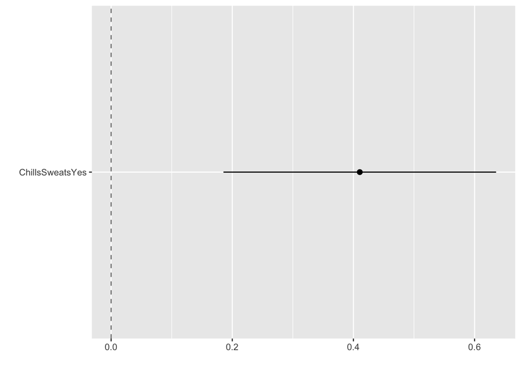

```r
tidy(lm_fit) %>%
dwplot(dot_args = list(size = 2, color = "black"),
         whisker_args = list(color = "black"),
         vline = geom_vline(xintercept = 0, colour = "grey50", linetype = 2))
```

# Model 2. Fitting a linear model to BodyTemp using all relevant predictors of interest If we remember from our EDA, the interesting predictors were

- CoughIntensity (none/mild/moderate/severe)
- ChillsSweats (y/n)
- SubjectiveFever (y/n)

*Note, I am not using Pharyngitis because if did not offer an interesting relationship in both body temperature variable alone as well as fever variable.

```r
# Using the tidymodels package, I am going to set up the linear model
# Set the engine
lm_mod <-  linear_reg() %>%
  set_engine("lm")
# Now I am fitting the model
lm_fit2 <-
  lm_mod %>%
  fit(BodyTemp ~ ChillsSweats * CoughIntensity * SubjectiveFever, data = processeddta)
tidy(lm_fit2)
```

```
## # A tibble: 16 × 5
##    term                                     estimate std.error statistic p.value
##    <chr>                                       <dbl>     <dbl>     <dbl>   <dbl>
##  1 (Intercept)                               98.3        0.391  252.       0
##  2 ChillsSweatsYes                           -0.119      0.517   -0.231    0.817
##  3 CoughIntensityMild                         0.135      0.475    0.283    0.777
##  4 CoughIntensityModerate                     0.196      0.431    0.455    0.649
##  5 CoughIntensitySevere                       0.277      0.475    0.583    0.560
##  6 SubjectiveFeverYes                         0.206      0.917    0.224    0.823
##  7 ChillsSweatsYes:CoughIntensityMild         0.215      0.620    0.346    0.729
##  8 ChillsSweatsYes:CoughIntensityModerate     0.178      0.565    0.314    0.753
##  9 ChillsSweatsYes:CoughIntensitySevere       0.342      0.628    0.545    0.586
## 10 ChillsSweatsYes:SubjectiveFeverYes         0.574      1.01     0.570    0.569
## 11 CoughIntensityMild:SubjectiveFeverYes     -0.451      1.03    -0.437    0.662
## 12 CoughIntensityModerate:SubjectiveFeverY…   0.0645     0.972    0.0663   0.947
## 13 CoughIntensitySevere:SubjectiveFeverYes    0.301      1.02     0.295    0.768
## 14 ChillsSweatsYes:CoughIntensityMild:Subj…   0.414      1.14     0.363    0.717
## 15 ChillsSweatsYes:CoughIntensityModerate:…  -0.344      1.07    -0.322    0.748
## 16 ChillsSweatsYes:CoughIntensitySevere:Su…  -0.851      1.13    -0.753    0.451
```

### Model as box and whiskers plot

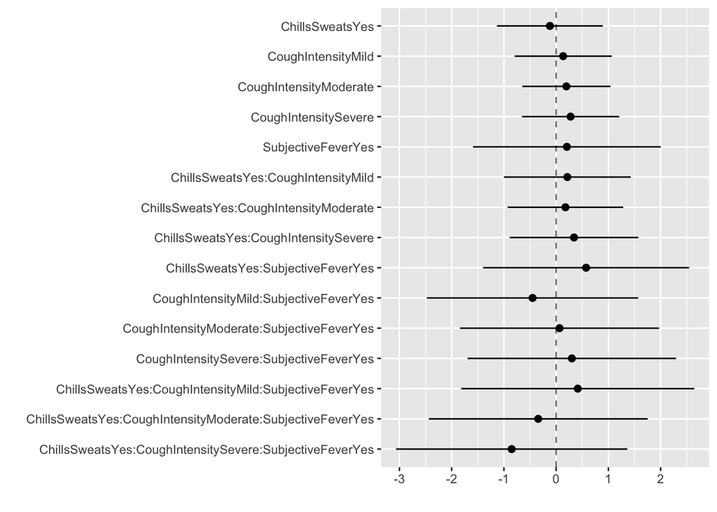

```r
tidy(lm_fit2) %>%
dwplot(dot_args = list(size = 2, color = "black"),
         whisker_args = list(color = "black"),
         vline = geom_vline(xintercept = 0, colour = "grey50", linetype = 2))
```

# Comparing Model 1 and Model 2

To best compare these models and see if they are significant, lets use an ANOVA table

```r
tidy(lm_fit)
```

```
## # A tibble: 2 × 5
##   term            estimate std.error statistic  p.value
##   <chr>              <dbl>     <dbl>     <dbl>    <dbl>
## 1 (Intercept)       98.6       0.104    947.   0
## 2 ChillsSweatsYes    0.410     0.115      3.58 0.000373
```

```r
tidy(lm_fit2)
```

```
## # A tibble: 16 × 5
##    term                                     estimate std.error statistic p.value
##    <chr>                                       <dbl>     <dbl>     <dbl>   <dbl>
##  1 (Intercept)                               98.3        0.391  252.       0
##  2 ChillsSweatsYes                           -0.119      0.517   -0.231    0.817
##  3 CoughIntensityMild                         0.135      0.475    0.283    0.777
##  4 CoughIntensityModerate                     0.196      0.431    0.455    0.649
##  5 CoughIntensitySevere                       0.277      0.475    0.583    0.560
##  6 SubjectiveFeverYes                         0.206      0.917    0.224    0.823
##  7 ChillsSweatsYes:CoughIntensityMild         0.215      0.620    0.346    0.729
##  8 ChillsSweatsYes:CoughIntensityModerate     0.178      0.565    0.314    0.753
##  9 ChillsSweatsYes:CoughIntensitySevere       0.342      0.628    0.545    0.586
## 10 ChillsSweatsYes:SubjectiveFeverYes         0.574      1.01     0.570    0.569
## 11 CoughIntensityMild:SubjectiveFeverYes     -0.451      1.03    -0.437    0.662
## 12 CoughIntensityModerate:SubjectiveFeverY…   0.0645     0.972    0.0663   0.947
## 13 CoughIntensitySevere:SubjectiveFeverYes    0.301      1.02     0.295    0.768
## 14 ChillsSweatsYes:CoughIntensityMild:Subj…   0.414      1.14     0.363    0.717
## 15 ChillsSweatsYes:CoughIntensityModerate:…  -0.344      1.07    -0.322    0.748
## 16 ChillsSweatsYes:CoughIntensitySevere:Su…  -0.851      1.13    -0.753    0.451
```

```r
ANOVA1<- anova(lm_fit$fit, lm_fit2$fit, test = "Chisq")
ANOVA1
```

```
## Analysis of Variance Table
##
## Model 1: BodyTemp ~ ChillsSweats
## Model 2: BodyTemp ~ ChillsSweats * CoughIntensity * SubjectiveFever
##   Res.Df     RSS Df Sum of Sq Pr(>Chi)
## 1    728 1025.38
## 2    714  981.82 14    43.557 0.004454 **
## ---
## Signif. codes:  0 '***' 0.001 '**' 0.01 '*' 0.05 '.' 0.1 ' ' 1
```

# Predicting fever temps using two different datasets

### Create model 2.2 with fever data set

```r
# First lets create a model with feverdta
lm_mod <-  linear_reg() %>%
  set_engine("lm")
# Now I am fitting the model
lm_fit2.2 <-
  lm_mod %>%
  fit(BodyTemp ~ ChillsSweats * CoughIntensity * SubjectiveFever, data = feverdta)
tidy(lm_fit2.2)
```

```
## # A tibble: 16 × 5
##    term                                   estimate std.error statistic   p.value
##    <chr>                                     <dbl>     <dbl>     <dbl>     <dbl>
##  1 (Intercept)                            102.         0.815  125.      6.08e-88
##  2 ChillsSweatsYes                          0.880      1.15     0.766   4.46e- 1
##  3 CoughIntensityMild                      -1.01       1.02    -0.990   3.25e- 1
##  4 CoughIntensityModerate                  -0.710      1.02    -0.696   4.89e- 1
##  5 CoughIntensitySevere                    -0.660      0.538   -1.23    2.24e- 1
##  6 SubjectiveFeverYes                      -1.02       0.791   -1.29    2.02e- 1
##  7 ChillsSweatsYes:CoughIntensityMild       0.920      1.56     0.589   5.58e- 1
##  8 ChillsSweatsYes:CoughIntensityModerate  -0.230      0.755   -0.304   7.62e- 1
##  9 ChillsSweatsYes:CoughIntensitySevere    NA         NA       NA      NA
## 10 ChillsSweatsYes:SubjectiveFeverYes      -0.0393     1.01    -0.0388  9.69e- 1
## 11 CoughIntensityMild:SubjectiveFeverYes   -0.153      1.56    -0.0978  9.22e- 1
## 12 CoughIntensityModerate:SubjectiveFeve…   0.750      1.12     0.671   5.04e- 1
## 13 CoughIntensitySevere:SubjectiveFeverY…  NA         NA       NA      NA
## 14 ChillsSweatsYes:CoughIntensityMild:Su…  NA         NA       NA      NA
## 15 ChillsSweatsYes:CoughIntensityModerat…  NA         NA       NA      NA
## 16 ChillsSweatsYes:CoughIntensitySevere:…  NA         NA       NA      NA
```

### Setting Predictions

```r
# Setting what we want to predict, a fever
new_points <- expand.grid(BodyTemp = 100.4,
                          CoughIntensity = c("None","Mild", "Moderate", "Severe"))
new_points
```

```
##   BodyTemp CoughIntensity
## 1    100.4           None
## 2    100.4           Mild
## 3    100.4       Moderate
## 4    100.4         Severe
```

### Set prediction for model 2

```r
mean_pred <- predict(lm_fit2$fit, new_data = new_points)
#Set Confidence Interval
confint <- predict(lm_fit2$fit,
                         new_data = new_points,
                         interval = 'confidence')
head(confint)
```

```
##        fit      lwr      upr
## 1 99.12727 98.43312 99.82143
## 2 99.12727 98.43312 99.82143
## 3 99.31579 99.07958 99.55200
## 4 99.09865 98.94448 99.25282
## 5 99.00417 98.53422 99.47411
## 6 99.09865 98.94448 99.25282
```

```r
tail(confint)
```

```
##          fit      lwr      upr
## 730 99.31579 99.07958 99.55200
## 731 98.54048 98.18523 98.89572
## 732 98.54048 98.18523 98.89572
## 733 98.84400 98.38355 99.30445
## 734 98.57419 98.16070 98.98769
## 735 99.09865 98.94448 99.25282
```

```r
#For some reason I am unable to bind mean_pred to confint for plotting and futher comparison
# So I am trowing in the towel on this one, but comparing outputs are interesting
```

### Set prediction for model 2.2

```r
mean_pred2 <- predict(lm_fit2.2$fit, new_data = new_points)
#Set Confidence Interval
confint2 <- predict(lm_fit2.2$fit,
                         new_data = new_points,
                        interval = 'confidence')
head(confint2)
```

```
##         fit      lwr      upr
## 2  100.5333  99.5370 101.5297
## 3  101.7913 101.4315 102.1511
## 5  102.0333 101.0370 103.0297
## 7  101.3737 100.9778 101.7696
## 14 101.3737 100.9778 101.7696
## 23 101.8440 101.4989 102.1891
```

```r
tail(confint2)
```

```
##          fit      lwr      upr
## 670 101.7913 101.4315 102.1511
## 687 101.7913 101.4315 102.1511
## 702 101.7913 101.4315 102.1511
## 707 103.0000 101.2743 104.7257
## 712 100.5333  99.5370 101.5297
## 728 101.7913 101.4315 102.1511
```

# Model 3. Fitting a logistic model to Nausea using Headache the main predictor of interest

```r
# Using the tidymodels package, I am going to set up the logistic model
# Set the engine
lm_mod1 <-  logistic_reg() %>%
  set_engine("glm")
# Now I am fitting the model
lm_fit3 <-
  lm_mod1 %>%
  fit(Nausea ~ Headache, data = processeddta)
tidy(lm_fit3)
```

```
## # A tibble: 2 × 5
##   term        estimate std.error statistic      p.value
##   <chr>          <dbl>     <dbl>     <dbl>        <dbl>
## 1 (Intercept)   -1.18      0.220     -5.37 0.0000000786
## 2 HeadacheYes    0.652     0.235      2.77 0.00556
```

### Model as box and whiskers plot

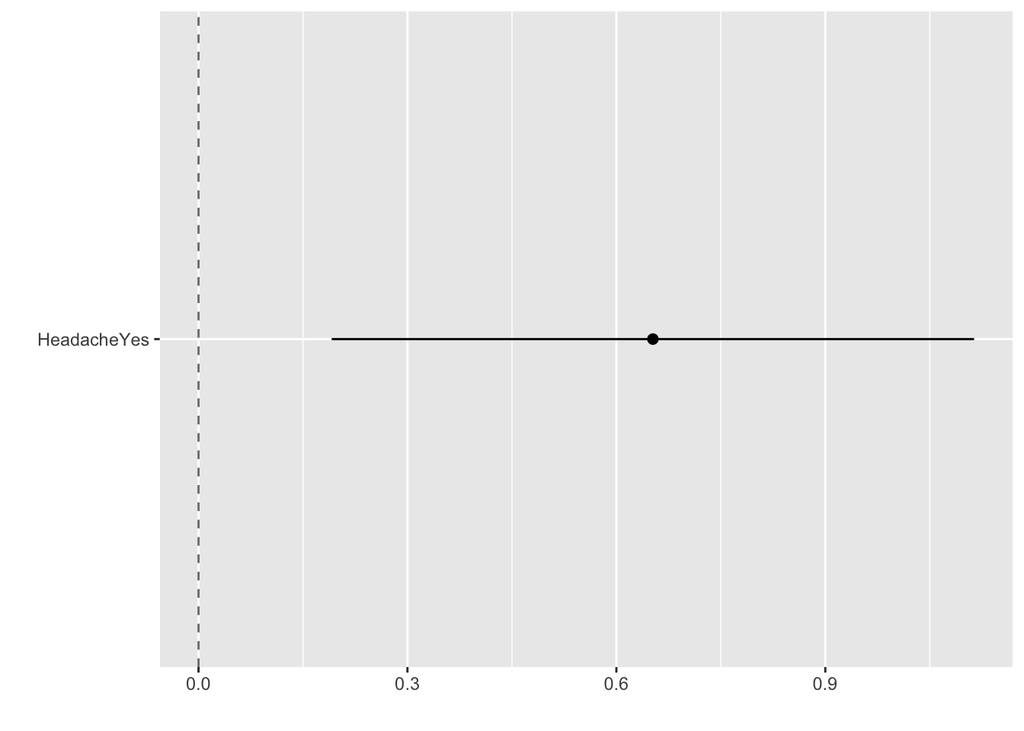

```r
tidy(lm_fit3) %>%
dwplot(dot_args = list(size = 2, color = "black"),
         whisker_args = list(color = "black"),
         vline = geom_vline(xintercept = 0, colour = "grey50", linetype = 2))
```

# Model 4. Fitting a logistic model to Nausea using all relevant predictors of interest

If we remember from our EDA, the interesting predictors were

- Fatigue
- ChillsSweats (y/n)
- SubjectiveFever (y/n)
- Pharyngitis

```r
# Using the tidymodels package, I am going to set up the linear model
# Set the engine
lm_mod1 <-  logistic_reg() %>%
  set_engine("glm")
# Now I am fitting the model
lm_fit4 <-
  lm_mod1 %>%
  fit(Nausea ~ ChillsSweats * Fatigue * SubjectiveFever* Pharyngitis, data = processeddta)
tidy(lm_fit4)
```

```
## # A tibble: 16 × 5
##    term                                     estimate std.error statistic p.value
##    <chr>                                       <dbl>     <dbl>     <dbl>   <dbl>
##  1 (Intercept)                              -1.56e+1     1455. -1.07e- 2   0.991
##  2 ChillsSweatsYes                           1.49e+1     1455.  1.02e- 2   0.992
##  3 FatigueYes                                1.38e+1     1455.  9.46e- 3   0.992
##  4 SubjectiveFeverYes                        7.28e-7     2058.  3.54e-10   1.00
##  5 PharyngitisYes                            1.36e+1     1455.  9.36e- 3   0.993
##  6 ChillsSweatsYes:FatigueYes               -1.36e+1     1455. -9.34e- 3   0.993
##  7 ChillsSweatsYes:SubjectiveFeverYes       -4.05e-1     2058. -1.97e- 4   1.00
##  8 FatigueYes:SubjectiveFeverYes            -1.38e+1     2301. -5.99e- 3   0.995
##  9 ChillsSweatsYes:PharyngitisYes           -1.40e+1     1455. -9.64e- 3   0.992
## 10 FatigueYes:PharyngitisYes                -1.29e+1     1455. -8.90e- 3   0.993
## 11 SubjectiveFeverYes:PharyngitisYes        -1.36e+1     2159. -6.31e- 3   0.995
## 12 ChillsSweatsYes:FatigueYes:Subjective…    1.41e+1     2301.  6.13e- 3   0.995
## 13 ChillsSweatsYes:FatigueYes:Pharyngiti…    1.31e+1     1455.  8.98e- 3   0.993
## 14 ChillsSweatsYes:SubjectiveFeverYes:Ph…    1.41e+1     2159.  6.55e- 3   0.995
## 15 FatigueYes:SubjectiveFeverYes:Pharyng…    2.74e+1     2391.  1.14e- 2   0.991
## 16 ChillsSweatsYes:FatigueYes:Subjective…   -2.74e+1     2391. -1.14e- 2   0.991
```